# Is it valid approach

Alexey Popov

13 января 2019 г

### А можно ли так делать?

Внимательный читатель может возразить, мол вы работаете не с самой случаной величиной, а с усреднением случаной величины по неравномерным интервалам. Причем усредненной очень грубо, на глаз. Фактически, всем тикетам, попадающим в определенный интервал мы присваиваем фиксированную оцеку, ближайшее к среднему целое, но не среднее. Да, это так. По идее, усреднение не должно нам сильно мешаеть. А вот грубое усреднение помешать может. (тут надо бы вставить немножко теории, но сейчас на это нет времени). Давайте проведем следственный эксперимент (это и быстрее, и убедительнее). Смоделируем выборку (нормально распределенную, с заданным средним и дисперсией), усредним по неравномерным интервалам и посмотрим, останется ли наше распределение нормально распределенным. После этого повторим эксперимент, но уже не усредняя оценки, а назначая некую фиксированную оценку для каждого интервала как это происходит на практике.

Сфорируем выборку сопоставимую по размерам с реальной, возьмем близкие среденее и дисперсию.

```r
z <- rnorm(1000, mean = 4, sd = 4)
mean(z)
```

```
## [1] 4.271338
```

```r
sd(z)
```

```
## [1] 4.050241
```

Как проверить, является ли данное распределение нормальным? Для наглядности построим гистограмму, посчитаем асимметрию и эксцесс.

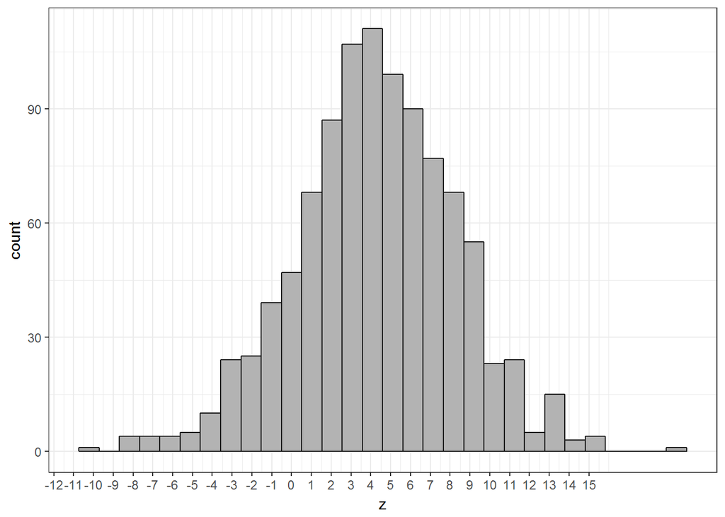

```r
ggplot() + geom_histogram(aes(x = z), fill = "gray70", colour = "gray10") +
  scale_x_continuous(breaks=seq(-15,15,by=1)) +
  theme_bw()
```

```r
skewness(z)
```

```
## [1] -0.1322676
```

```r
kurtosis(z)
```

```
## [1] 3.342509
```

Как можно видеть - все прекрасно. Асимметрия нулевая, эксцесс ~3.

Проведем тестированием используя критерия согласия Хи-квадрат (критерий Пирсона). Используем готовый тест и дополнительно посчитаем критерий согласия вручную.

```r
# теоретическая плотность вероятности
chi_c <- c(pnorm(0, mean = 4, sd = 4),
           pnorm(0.25, mean = 4, sd = 4) - pnorm(0, mean = 4, sd = 4),
           pnorm(0.75, mean = 4, sd = 4) - pnorm(0.25, mean = 4, sd = 4),
           pnorm(1.5, mean = 4, sd = 4) - pnorm(0.75, mean = 4, sd = 4),
           pnorm(3, mean = 4, sd = 4) - pnorm(1.5, mean = 4, sd = 4),
           pnorm(6, mean = 4, sd = 4) - pnorm(3, mean = 4, sd = 4),
           pnorm(12, mean = 4, sd = 4) - pnorm(6, mean = 4, sd = 4),
           pnorm(20, mean = 4, sd = 4) - pnorm(12, mean = 4, sd = 4),
           1 - pnorm(20, mean = 4, sd = 4))

# плотность распределения по модельным данным (не нормированная)
chi_o <- c(sum((z<=0)),
             sum((z>0) & (z<=0.25)),
             sum((z>0.25) & (z<=0.75)),
             sum((z>0.75) & (z<=1.5)),
             sum((z>1.5) & (z<=3)),
             sum((z>3) & (z<=6)),
             sum((z>6) & (z<=12)),
             sum((z>12) & (z<=20)),
             sum((z>20)))

# встроенный тест
chisq.test(x = chi_o, p = chi_c)
```

```
##
##  Chi-squared test for given probabilities
##
## data:  chi_o
## X-squared = 9.9569, df = 8, p-value = 0.2681
```

```r
# посчитаем Хи-квадрат вручную, критическое значение K = 18.54 для p = 0.05 и выбранного количества интервалов.
sum(((chi_o[1:9] - chi_c[1:9]*length(z))^2)/(chi_c[1:9]*length(z)))
```

```
## [1] 9.95691
```

В соответствии с критерием Пирсона наше модельное распределение явсляется нормальным. Критерий Хи-квадрат вычисленный вручную и вычисленный в рамках теста равны.

Проведем еще два популярных теста: Шапиро-Уилка и Харке-Бера (используеющих асиммметрию и эксцесс):

```r
jarque.test(z)
```

```
##
##  Jarque-Bera Normality Test
##
## data:  z
## JB = 7.8038, p-value = 0.0202
## alternative hypothesis: greater
```

```r
shapiro.test(z)
```

```
##
##  Shapiro-Wilk normality test
##
## data:  z
## W = 0.99728, p-value = 0.09102
```

```r
lillie.test(z)
```

```
##
##  Lilliefors (Kolmogorov-Smirnov) normality test
##
## data:  z
## D = 0.033176, p-value = 0.01145
```

```r
pearson.test(z)
```

```
##
##  Pearson chi-square normality test
##
## data:  z
## P = 26.752, p-value = 0.5851
```

Теперь вместо реальных случайных значений подставим в нашу выборку ближайшее среднее по неравномерным интервалам. И снова проверим параметры выборки и проведем тесты. Понятно, что выбор интервалов усреденния тоже может играть роль, поэтому выберем интервалы, близкие к тем, что получаются на практике.

```r
# сохраним исходную выборку
z0 <- z

# усредним по интервалам
z[(z<=0)] <- mean(z[(z<=0)])
z[(z>0) & (z<=0.25)] <- mean(z[(z>0) & (z<=0.25)])
z[(z>0.25) & (z<=0.75)] <- mean(z[(z>0.25) & (z<=0.75)])
z[(z>0.75) & (z<=1.5)] <- mean(z[(z>0.75) & (z<=1.5)])
z[(z>1.5) & (z<=3)] <- mean(z[(z>1.75) & (z<=3)])
z[(z>3) & (z<=6)] <- mean(z[(z>3) & (z<=6)])
z[(z>6) & (z<=12)] <- mean(z[(z>6) & (z<=12)])
z[(z>12) & (z<=20)] <- mean(z[(z>12) & (z<=20)])
z[(z>20)] <- mean(z[(z>20)])

mean(z)
```

```
## [1] 4.278435
```

```r
sd(z)
```

```
## [1] 3.847148
```

Среднее не изменилось, слегка уменьшилась дисперсия.

Проверим выборку по критерию Хи-квадрат.

```r
# плотность распределения по модельным данным (не нормированная)
chi_o <- c(sum((z<=0)),
             sum((z>0) & (z<=0.25)),
             sum((z>0.25) & (z<=0.75)),
             sum((z>0.75) & (z<=1.5)),
             sum((z>1.5) & (z<=3)),
             sum((z>3) & (z<=6)),
             sum((z>6) & (z<=12)),
             sum((z>12) & (z<=20)),
             sum((z>20)) )

# встроенный тест
chisq.test(x = chi_o, p = chi_c)
```

```
##
##  Chi-squared test for given probabilities
##
## data:  chi_o
## X-squared = 9.9569, df = 8, p-value = 0.2681
```

```r
# посчитаем Хи-квадрат вручную, критическое значение K = 18.54 для p = 0.05 и выбранного количества интервалов.
sum(((chi_o[1:9] - chi_c[1:9]*length(z))^2)/(chi_c[1:9]*length(z)))
```

```
## [1] 9.95691
```

Критерий Хи-квадрат меньше критической точки (K = 18.5). P-значение значительно больше 0.05.

Проверим асимметрию и экцесс.

```r
skewness(z)
```

```
## [1] -0.08799657
```

```r
kurtosis(z)
```

```
## [1] 2.588419
```

Асимметрий близка к нулю, а эксцесс немного уменьшился.

А что нам покажут тесты Харке-Бера, Шапиро-Уилка и Колмогорова-Смирнова?

```r
jarque.test(z)
```

```
##
##  Jarque-Bera Normality Test
##
## data:  z
## JB = 8.3488, p-value = 0.01538
## alternative hypothesis: greater
```

```r
shapiro.test(z)
```

```
##
##  Shapiro-Wilk normality test
##
## data:  z
## W = 0.90637, p-value < 2.2e-16
```

```r
lillie.test(z)
```

```
##
##  Lilliefors (Kolmogorov-Smirnov) normality test
##
## data:  z
## D = 0.17589, p-value < 2.2e-16
```

```r
pearson.test(z)
```

```
##
##  Pearson chi-square normality test
##
## data:  z
## P = 6196.1, p-value < 2.2e-16
```

Тесты уже отказываются считать данное распределение нормальным.

Для наглядности построим распределение.

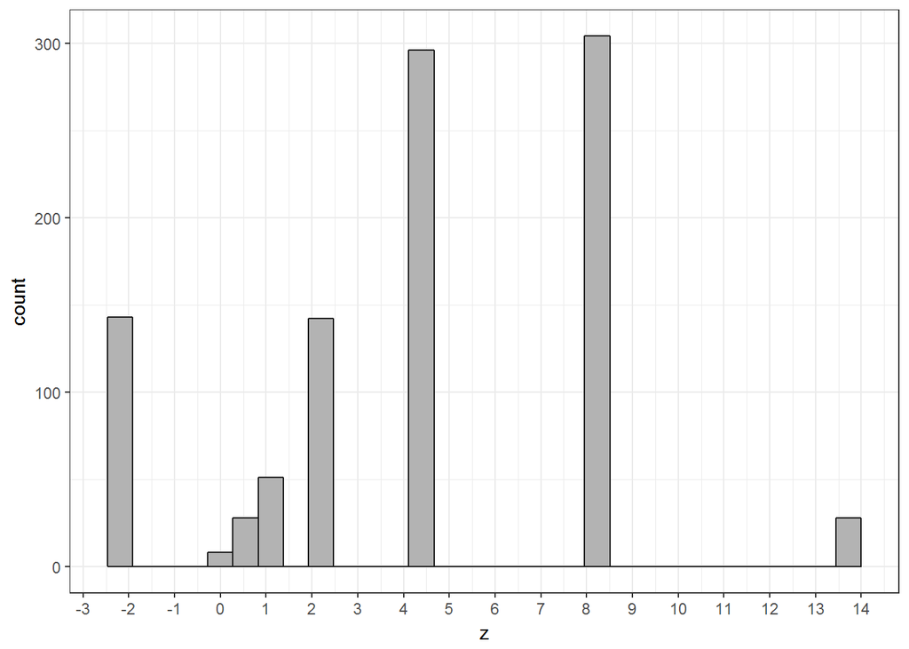

```r
ggplot() + geom_histogram(aes(x = z), fill = "gray70", colour = "gray10") +
  scale_x_continuous(breaks=seq(-15,25,by=1)) +
  theme_bw()
```

Теперь повторим эксперимент, но уже использую фиксированную оценку для всех тикетов из заданного интервала.

```r
z <- z0
z[(z<=0)] <- mean(z[(z<=0)])
z[(z>0) & (z<=0.25)] <- 0.1
z[(z>0.25) & (z<=0.75)] <- 0.5
z[(z>0.75) & (z<=1.5)] <- 1
z[(z>1.5) & (z<=3)] <- 2
z[(z>3) & (z<=6)] <- 4
z[(z>6) & (z<=12)] <- 8
z[(z>12) & (z<=20)] <- 16
z[(z>20)] <- 24

#z <- z[z>0]

mean(z)
```

```
## [1] 4.082559
```

```r
sd(z)
```

```
## [1] 4.012751
```

```r
chi_o <- c(sum((z<=0)),
             sum((z>0) & (z<=0.25)),
             sum((z>0.25) & (z<=0.75)),
             sum((z>0.75) & (z<=1.5)),
             sum((z>1.5) & (z<=3)),
             sum((z>3) & (z<=6)),
             sum((z>6) & (z<=12)),
             sum((z>12) & (z<=20)),
             sum((z>20)) )

# встроенный тест
chisq.test(x = chi_o, p = chi_c)
```

```
##
##  Chi-squared test for given probabilities
##
## data:  chi_o
## X-squared = 9.9569, df = 8, p-value = 0.2681
```

```r
# посчитаем Хи-квадрат вручную, критическое значение K = 18.54 для p = 0.05 и выбранного количества интервалов.
sum(((chi_o[1:9] - chi_c[1:9]*length(z))^2)/(chi_c[1:9]*length(z)))
```

```
## [1] 9.95691
```

```r
skewness(z)
```

```
## [1] 0.3662757
```

```r
kurtosis(z)
```

```
## [1] 3.439628
```

```r
jarque.test(z)
```

```
##
##  Jarque-Bera Normality Test
##
## data:  z
## JB = 30.413, p-value = 2.489e-07
## alternative hypothesis: greater
```

```r
shapiro.test(z)
```

```
##
##  Shapiro-Wilk normality test
##
## data:  z
## W = 0.89576, p-value < 2.2e-16
```

```r
lillie.test(z)
```

```
##
##  Lilliefors (Kolmogorov-Smirnov) normality test
##
## data:  z
## D = 0.17621, p-value < 2.2e-16
```

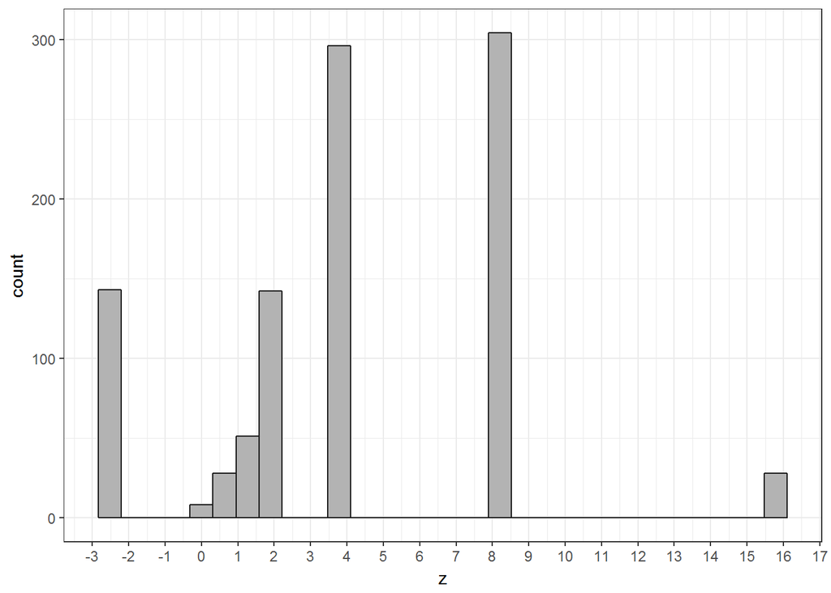

```r
ggplot() + geom_histogram(aes(x = z), fill = "gray70", colour = "gray10") +
  scale_x_continuous(breaks=seq(-15,25,by=1)) +
  theme_bw()
```

### Заключение

Таким образом, даже если исходная оценка трудозатрат распределена нормальна, наша метрика не является нормлаьно распределенной, так как усреднение (а тем более присвоение ближайшего целого к среднему) по интервалам ее “портит”.